# 7_Lab_Bootstrap

Lemar Popal

March 9, 2019

```r
library(tidyverse)
library(lubridate)
library(modelr)
library(broom)

set.seed(35)
```

1. Import Data

```r
# Read in the data
my_path <- "/Users/lemarpopal/Desktop/github/STAT-331/sf-salaries/"

salaries <- read.csv(paste0(my_path, "Salaries.csv"), header=TRUE, na=c("Not Provided", "Not provided"))
```

2. Plot a histogram of Total Pay with an overlaying density. Note: Some outliers at the far end of the histogram are cut off by the xlim() function so we could zoom in on where the bulk of the data is.

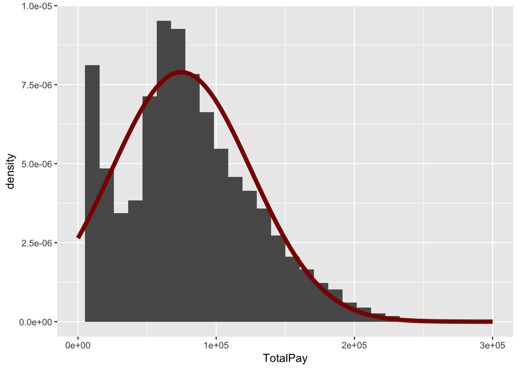

```r
salaries %>%
  ggplot(aes(x=TotalPay)) + geom_histogram(aes(y= ..density..)) + stat_function(fun = dnorm, args = list(mean = mean(salaries$TotalPay), sd = sd(salaries$TotalPay)), color = "darkred", size = 2) + xlim(0, 3*(10**5))
```

3. The mean may not be a good statistic to use here. The mean is particularly susceptible to outliers. This means that if there are really small or large salaries, the mean will be pulled towards the outlier, either left or right. A more appropriate statistic to use is the median, which is a value where half the salaries are below, and the other half are above. The median is much more resistant to being affected by outliers, because even if there are very far out outliers, the median will not move much.
4. This does not seem resonable. In the sample of salaries in the plot above, we can see that the histogram does not fit under the normal curve very well. It looks like the distribution is bimodal (two peaks). Thus, we cannot conclude that the population is normally distributed.
5. Compute a 95% t-confidence interval for the mean Total Pay.

```r
tidy(t.test(salaries$TotalPay)) %>% select(conf.low, conf.high)
```

```
## # A tibble: 1 x 2
##   conf.low conf.high
##      <dbl>     <dbl>
## 1   74512.    75025.
```

6. Use the bootstrap procedure to construct a 95% bootstrap confidence interval for the mean Total Pay. Compare this interval to your t-interval in (3). Be sure to explain any differences you see.

```r
salaries_boots <- replicate(1000, sample(salaries$TotalPay, replace=TRUE), simplify = FALSE)
```

```r
salaries_stats <- data.frame(
  means = map_dbl(salaries_boots, mean),
  medians = map_dbl(salaries_boots, median)
)
```

```r
quantile(salaries_stats$means, c(0.025, .975))
```

```
##     2.5%    97.5%
## 74512.12 75036.40
```

This confidence interval tells us that we are 95% confident that the population mean of Total Pay is between $74512 and $75036. The bootstrap interval is slightly wider.

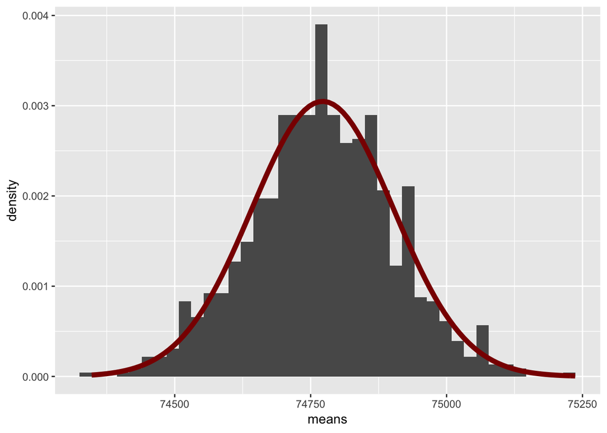

```r
salaries_stats %>%
  ggplot(aes(x=means)) + geom_histogram(aes(y= ..density..), bins=40) + stat_function(fun = dnorm, args = list(mean = mean(salaries_stats$means), sd = sd(salaries_stats$means)), color = "darkred", size = 2)
```

```r
# Midhinge = (Q1 + Q3) / 2
calc_midhinge <- function(data) {

  Q1 = quantile(data, 0.25)
  Q3 = quantile(data, 0.75)

  return(as.numeric(Q1 + Q3) / 2)
}

# Trimmed Mean
calc_trimmed_mean <- function(data, percent) {

  # divide by 100 to get a number between 0 and 1
  percent = percent / 100

  # in order to trim data off ends, we first need to sort the vector
  sorted_data = sort(data)

  # determine how many observations to trim off each end of sorted vector
  num_to_remove = floor(percent * length(sorted_data))

  trimmed_data = sorted_data[num_to_remove : length(sorted_data)-num_to_remove]

  return(mean(trimmed_data))
}
```

8. Perform the bootstrap procedure and produce graphs of the distributions.

```r
bootstrapped_df <- data.frame(
  midhinge = map_dbl(salaries_boots, calc_midhinge),
  trimmed_mean_5 = map_dbl(salaries_boots, ~calc_trimmed_mean(., 5)),
  trimmed_mean_10 = map_dbl(salaries_boots, ~calc_trimmed_mean(., 10)),
  trimmed_mean_25 = map_dbl(salaries_boots, ~calc_trimmed_mean(., 25)),
  median = map_dbl(salaries_boots, median)
)
```

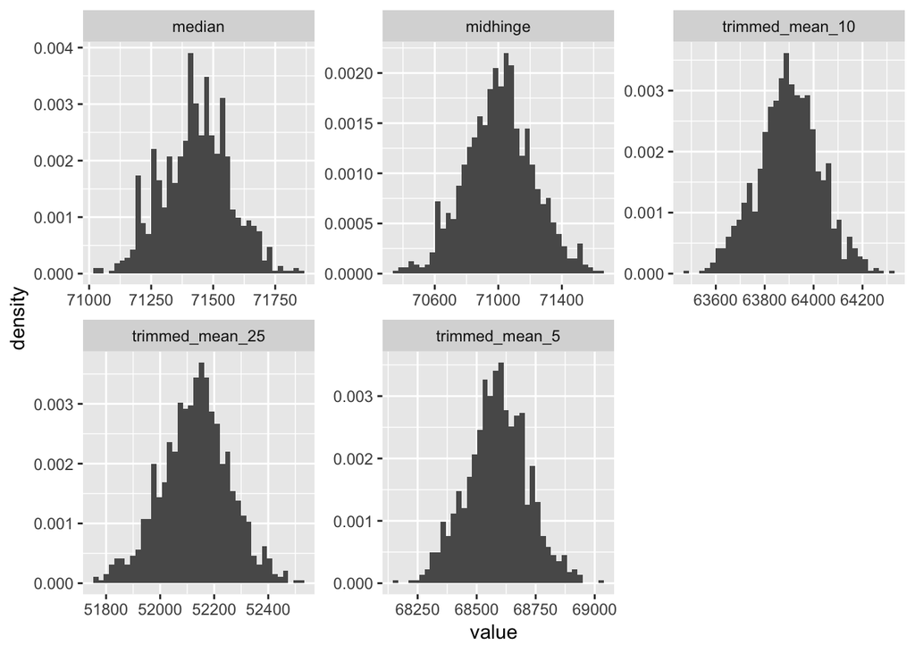

```r
bootstrapped_gathered_df <- bootstrapped_df %>% gather(key="distribution", value="value")

ggplot(bootstrapped_gathered_df, aes(x=value)) + geom_histogram(aes(y= ..density..), bins=40) + facet_wrap(~ distribution, scales="free")
```

```r
results <- map(bootstrapped_df, ~quantile(., c(0.025, .975)))

# convert named list of results to data frame and add names
t <- data.frame(matrix(unlist(results), nrow=length(results), byrow=T))
t <- t %>%
  rename(
    conf.low = X1,
    conf.high = X2
  )
rownames(t) <- c("midhinge", "5% Trimmed mean", "10% Trimmed mean", "25% Trimmed mean", "median")
t
```

```
##                  conf.low conf.high
## midhinge         70603.39  71447.50
## 5% Trimmed mean  68327.95  68852.48
## 10% Trimmed mean 63638.75  64158.31
## 25% Trimmed mean 51863.63  52385.52
## median           71178.10  71691.69
```